# BIOST 561: error handling and profiling code

Lecture 6

# Announcements

- Your HW2 graded! You all did great!
- You probably got an email from `UW Course Evaluations via IASystem Notification` about this course’s midterm course feedback. It would mean a lot to me if you filed it out
- HW3 has been released

# Quick notes on HW3:

- **VERY IMPORTANT:** Make sure you can set up https://uwconnect.uw.edu/it?id=kb_article_view&sysparm_article=KB0034247. This is very important for HW4.
- There’s a Google Docs walkthrough for setting up your R package (which is stated in HW3): https://docs.google.com/document/d/103ayPYvyzXHa84YFt-cQm_hMM1Ukqo7hlUygYD6UnC0/edit?usp=sharing.
- You might find this useful when doing HW3

# The general workflow of unit testing

Question about what’s the high-level takeaway on when/how-much to unit test:

- Write your function to a point where you think “it works”
- Write one unit test, starting from the “simplest and lowest-level” functions (typicall your helper functions), testing for just completion – does my function even complete for the simplest possible input?
- Work your way up to writing a test of completion for your main function (the “main” function)

# The general workflow of unit testing

Question about what’s the high-level takeaway on when/how-much to unit test:

- Write your function to a point where you think “it works”
- Write one unit test, starting from the “simplest and lowest-level” functions (typicall your helper functions), testing for just completion – does my function even complete for the simplest possible input?
- Work your way up to writing a test of completion for your main function (the “main” function)
- Often, some function’s output are the input of other functions. Hence, write tests starting from the “functions that are used first.”
- Then, each function has one (very simple) unit test. Now, whenever possible, write one unit test for each function that demonstrates its “correctness”. This will be conceptually easier to do for some function than others. The more “self-evidently correct” a function is (i.e., it’s so simple that there’s no way there’s a bug), the less tests you need to write for that function.
- Eventually, you’ll work up to write a test of correctness for your main function. (At this point, it might not be “strong certification” of correctness, but you should have some confidence that your function is probably doing something reasonable at this point. You’ve written some simple tests for completion and correctness for the main function and all the helper functions it depends on.)
- During this process, write some unit tests that verify things that you’re really scared of happening. (As you get more experience in coding, you’ll know what will scare you.)

# The general workflow of unit testing

Question about what’s the high-level takeaway on when/how-much to unit test:

# Aside: Using pipes “properly” in your R package

- To use pipes (i.e., `%>%`) in your R package, you simply need to run (in your R project that is for your R package) `usethis::use_pipe()` followed by `devtools::document()`. This does all the setup you need in your package so you can use `%>%` as usual within your function.
- See https://usethis.r-lib.org/reference/use_pipe.html
- This is what the function looks like (when you run in the R console)

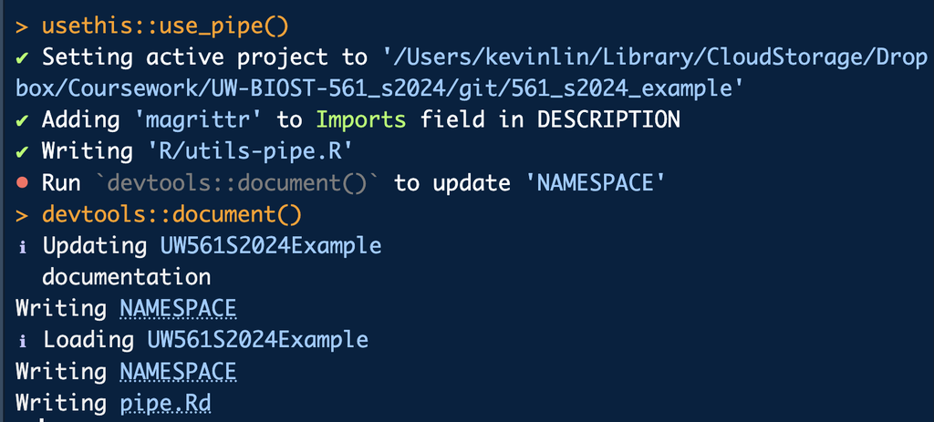

- This adds a few changes to your R package.
- The first the addition of a `R/utils-pipe.R` file:

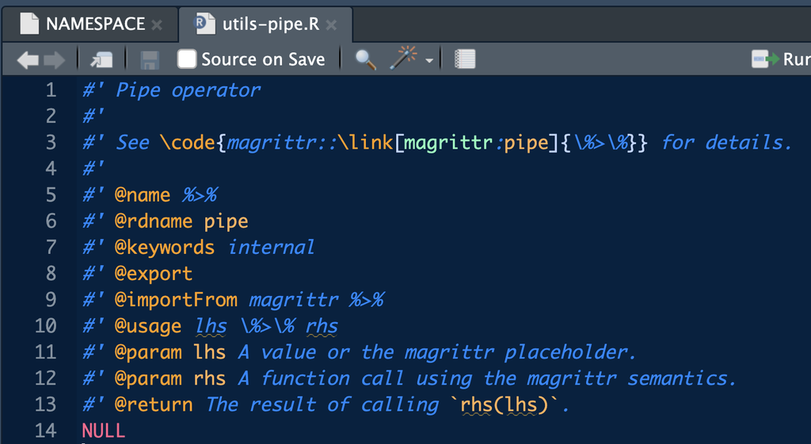

- The second is adding some extra lines to the `NAMESPACE` file:

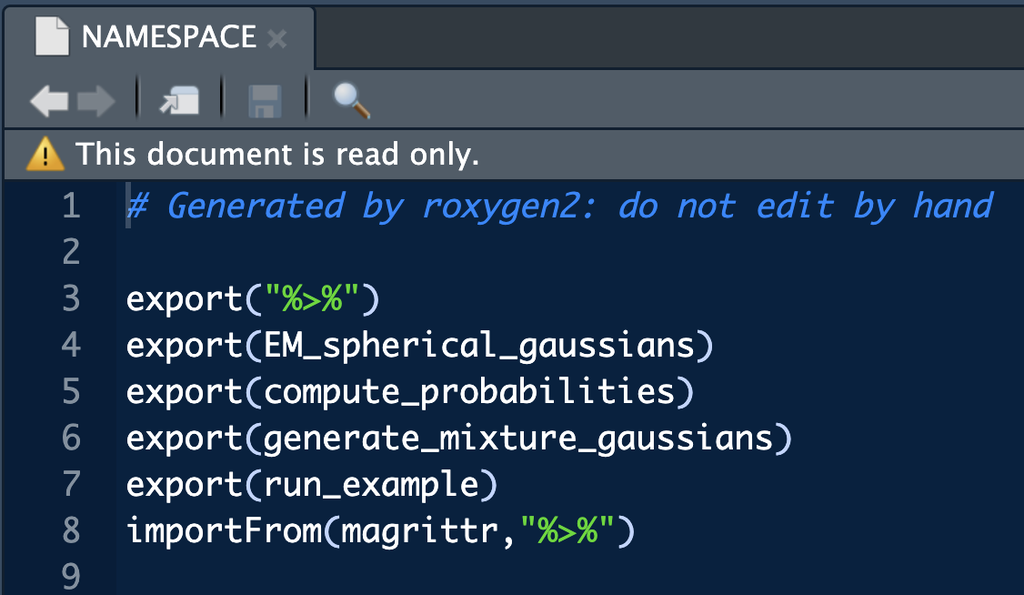

- (It also makes sure that `magittr` is in your `DESCRIPTION` file under `Imports:`)

# How to install your R package

- To install your R package, simply run `devtools::install()` in your R console.
- Similar to running `devtools::test()` or `devtools::test()`, you need to make sure you’re in the R project for your R package.

[figure not shown]

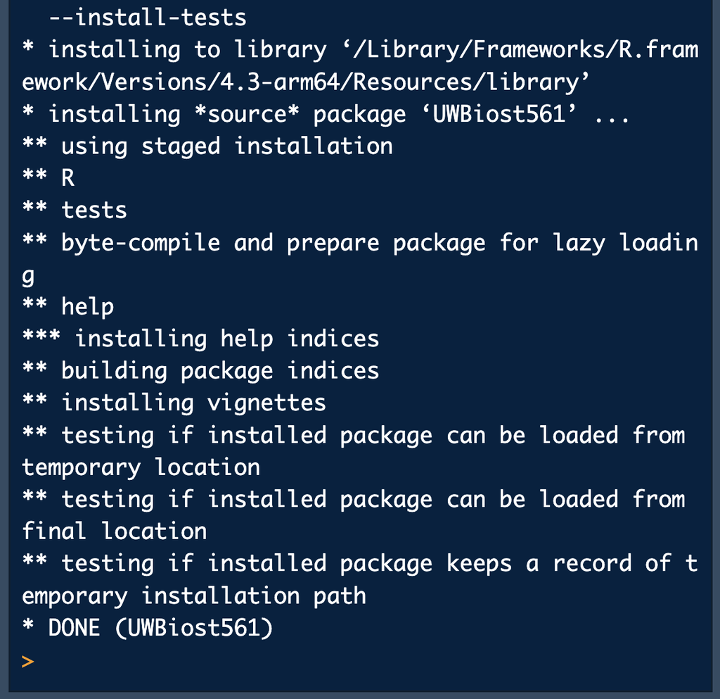

- And then you can use your package as you would any other package!
- For example, you can then use `library(UWBiost561)` in your R Markdown file!

# Let’s go on break

We’ll go on break, and then:

- Finish going over Homework 3
- Do an in-class discussing with your table-mates on last week’s in-class exercise about how to test bootstrapped confidence intervals.

Then:

- A few more things about function design
- Adding meaningful “print” statements while your function is being used
- `TryCatch`: how your function gracefully handles errors and warnings from other functions
- Setting a time limit on your function
- Optimizing/profiling your code
- How and when you need to optimize your function
- How to profile your function
- Some examples

# Adding “verbose” statements in your functions

- When you write a function with a big loop, you might often want to print out the progress of that function (so you know what’s going on)
- The most common way I do this is to print out statements
- The following function is to compute bootstrapped confidence intervals for linear regression coefficients
- Notice we can put print statements inside the function
- This statement only triggers when `verbose > 0`

```
bootstrap_lm <- function(X, y,
                         alpha = 0.05,
                         nboot = 1000,
                         verbose = 0){
  n <- nrow(X)
  coef_mat <- matrix(NA,
                     ncol = ncol(X) + 1,
                     nrow = nboot)

  if(verbose > 0) print("Starting bootstrap")
  for(i in 1:nboot){
    if(verbose > 0 && nboot > 10 && i %% floor(nboot/10) == 0) cat('*')
    idx <- sample(1:n, n, replace = TRUE)
    X2 <- X[idx,]
    y2 <- y[idx]
    lm_res <- stats::lm(y2 ~ X2)
    coef_mat[i,] <- stats::coef(lm_res)
  }

  if(verbose > 0) cat("\nComputing the CI\n")
  quantile_mat <- apply(coef_mat, 2, function(x){
    stats::quantile(x, probs = c(alpha/2, 1-alpha/2))
  })
  colnames(quantile_mat) <- c("(Intercept)", colnames(X))

  return(quantile_mat)
}
```

- We can also print out stars as our function progresses
- This is helpful since we can visually see what the progress is
- These print statements only trigger if 1) there are more than 10 bootstrap trials (i.e., `nboot > 10`), and 2) we have completed an additional 1/10th of the bootstrap trials (i.e., `i %% floor(nboot/10) == 0`)

```
bootstrap_lm <- function(X, y,
                         alpha = 0.05,
                         nboot = 1000,
                         verbose = 0){
  n <- nrow(X)
  coef_mat <- matrix(NA,
                     ncol = ncol(X) + 1,
                     nrow = nboot)

  if(verbose > 0) print("Starting bootstrap")
  for(i in 1:nboot){
    if(verbose > 0 && nboot > 10 && i %% floor(nboot/10) == 0) cat('*')
    idx <- sample(1:n, n, replace = TRUE)
    X2 <- X[idx,]
    y2 <- y[idx]
    lm_res <- stats::lm(y2 ~ X2)
    coef_mat[i,] <- stats::coef(lm_res)
  }

  if(verbose > 0) cat("\nComputing the CI\n")
  quantile_mat <- apply(coef_mat, 2, function(x){
    stats::quantile(x, probs = c(alpha/2, 1-alpha/2))
  })
  colnames(quantile_mat) <- c("(Intercept)", colnames(X))

  return(quantile_mat)
}
```

- Let’s use it

```r
ctl <- c(4.17,5.58,5.18,6.11,4.50,4.61,5.17,4.53,5.33,5.14)
trt <- c(4.81,4.17,4.41,3.59,5.87,3.83,6.03,4.89,4.32,4.69)
group <- matrix(c(rep(0, 10), rep(1, 10)), ncol = 1)
colnames(group) <- "group"

weight <-  c(ctl, trt)

res <- bootstrap_lm(X = group,
                    y = weight,
                    verbose = 1)
```

```
## [1] "Starting bootstrap"
## **********
## Computing the CI
```

```r
res
```

```
##       (Intercept)      group
## 2.5%     4.678393 -0.8992083
## 97.5%    5.392869  0.2576288
```

- Notice that we now have print statements!
- See https://cran.r-project.org/web/packages/progressr/vignettes/progressr-intro.html for other fancier packages that help you visualize a progress bar

# `tryCatch()`: outputting even when the code crashes

- Sometimes you’re using **someone else’s** function many, many times, and that function sometimes unexpectedly crashes given specific inputs. Uh oh!
- Sad day for you. Unfortunately, you can’t control how other coders behave.
- What should you do?

The “unlucky” universe: If their function rarely works for most inputs, you’re probably out of luck – you don’t have many great options

- **Option 1 (Re-implement)**: Since R is open-source, you can look at their implementation, copy-paste their implementation into your R package (of course, citing their work!), and manually fixing their code. This way, you don’t need to start from ground-zero, but this will still realistically be a lot of work. Do-able, but painful.
- **Option 2 (Search elsewhere)**: To look online at other implementations of the same or similar problems. Maybe someone else coded a different function that works. (This is why as you code more, you’ll become more and more used to reading other people’s code. This is also where your colleagues and advisors might have some suggestions.)
- **Option 3 (Consider alternative paths)**: You might need change your entire strategy on how to solve your problem. (This is actually the most common route you’ll pick.) There are many paths to solve a problem, and unfortunately, the path you set out was more thorny than you had realized.

The “not great, but not that bad” universe: If their function works as intended for **most** inputs, you can still use their function as long as you’re somewhat clever.

- **Option 1 (Thorough understanding)**: If you somehow spent time to figure out **why** the function sometimes unexpectedly crashes (typically in a “corner case”), then you can simply avoid calling the function in this special settings.

```r
# (This is fictitious pseudo-code)
my_function <- function(input){
  # check if the input is a corner case for someone_elses_function()
  if(check_argument(input)){

    # my custom code to handle this corner case
  } else {

    # otherwise, use someone_elses_function()
    someone_elses_function(input)
  }
}
```

- **Option 2 (TryCatch)**: You can “wrap” their function in a `tryCatch()`, whereby you write code that executes specifically when their function errors. (This is a common route to pick since this doesn’t require you completely understand why their function crashed. However, the tradeoff is that this means you’ll **always** be trying to use their function regardless of if the inputs are appropriate, which might make the overall function slower. If you can pick Option 1, I’ll always encourage choosing Option 1 over Option 2.)

```r
# (This is fictitious pseudo-code)
my_function <- function(input){
  tryCatch(someone_elses_function(input),
           error = function(e){
             # do something else with input
           })
}
```

# Examples of `tryCatch()` in action

I’ll give two examples of how to use `tryCatch()`.

The typical workflow of a `tryCatch()` function is:

```r
tryCatch(
  {
    ## Write code here that you hope to use
    ## If this is ONE function call (i.e., NOT a many lines of code)
    ## then you don't need the {}'s.
    ## However, you'll still need the comma at the end
  },
  error = function(e){
    # Write code here on what to do in case the first
    # code block crashed
  }
)
```

(It’s a longer discussion that I won’t get to on why you’re writing `error=function(e){}`. This has to do with signals and conditions in R.)

# Example 1: Error when using K-means clustering

- K-means clustering clusters a bunch of rows of a matrix in a “meaningful” way. (You will learn this in some machine learning class in the future, if you haven’t already)
- The `stats::kmeans()` function usually works pretty well for this.

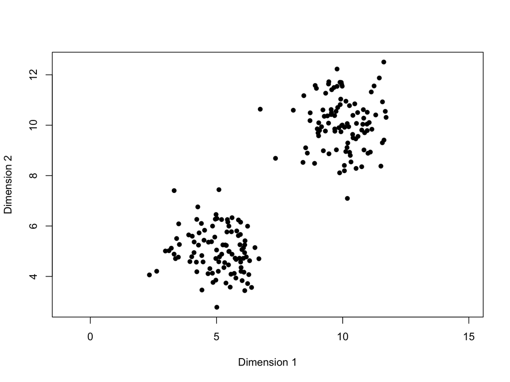

```r
set.seed(0)
mat_list <- lapply(1:2, function(k){
  MASS::mvrnorm(n = 100,
                mu = rep(k*5, 2),
                Sigma = diag(2))
})
mat <- do.call(rbind, mat_list)
plot(mat[,1],
     mat[,2],
     asp = TRUE,
     pch = 16,
     xlab = "Dimension 1",
     ylab = "Dimension 2")
```

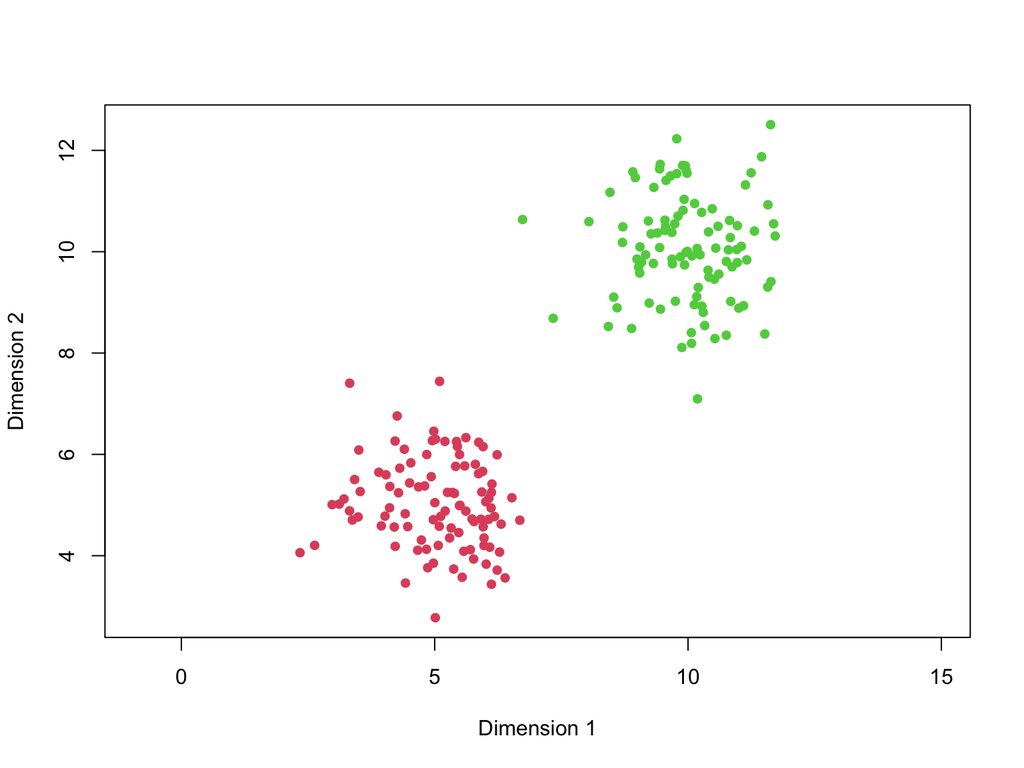

```r
kmeans_res <- stats::kmeans(mat,
                            centers = 2)
plot(mat[,1],
     mat[,2],
     asp = TRUE,
     pch = 16,
     col = kmeans_res$cluster+1,
     xlab = "Dimension 1",
     ylab = "Dimension 2")
```

- However, the `stats::kmeans()` function is known to crash when there are more cluster centers requested than distinct data points.

```r
mat_constant <- cbind(rep(1, 10),
                      rep(2, 10))
# each row of mat_constant is exactly c(1,2)
mat_constant
```

```
##       [,1] [,2]
##  [1,]    1    2
##  [2,]    1    2
##  [3,]    1    2
##  [4,]    1    2
##  [5,]    1    2
##  [6,]    1    2
##  [7,]    1    2
##  [8,]    1    2
##  [9,]    1    2
## [10,]    1    2
```

```r
kmeans_res <- stats::kmeans(mat_constant,
                            centers = 2)
```

```
## Error in stats::kmeans(mat_constant, centers = 2): more cluster centers than distinct data points.
```

- If you’re using this function many many times on different datasets, you might not realize some datasets are “degenerate” in this sense
- For those of you doing research: Specifically for clustering, this is a **very common** encountered error when you’re developing a sub-sampling procedure for clustering (either sub-sampling rows or columns of a matrix, and then doing the clustering)
- To get around this, you might add a random amount of “jitter” to the data only if `stats::kmeans()` crashes.

```r
kmeans_safe <- function(mat, centers){
  tryCatch(
    stats::kmeans(mat,
                  centers = centers),
    error = function(e){
      mat_tmp <- apply(mat, 2, function(x){
        n <- length(x)
        sd_val <- stats::sd(x)
        if(sd_val == 0) sd_val <- 0.01
        x_new <- x + stats::rnorm(n,
                                  mean = 0,
                                  sd = sd_val/10)

        return(x_new)
      })

      stats::kmeans(mat_tmp,
                    centers = centers)
    }
  )
}

kmeans_res <- kmeans_safe(mat_constant,
                          centers = 2)
kmeans_res$cluster
```

```
##  [1] 2 2 1 1 1 1 1 1 2 2
```

# Example 2: Error when computing the inverse of a matrix

- Suppose I’m computing the inverse of a matrix via `solve()`. This works most of the time as intended.

```r
mat1
```

```
##      [,1] [,2] [,3]
## [1,]    2    1    1
## [2,]    1    2    0
## [3,]    1    0    2
```

```r
inverse1 <- solve(mat1)
inverse1
```

```
##      [,1]  [,2]  [,3]
## [1,]  1.0 -0.50 -0.50
## [2,] -0.5  0.75  0.25
## [3,] -0.5  0.25  0.75
```

```r
# it's indeed the inverse!
inverse1 %*% mat1
```

```
##      [,1] [,2] [,3]
## [1,]    1    0    0
## [2,]    0    1    0
## [3,]    0    0    1
```

```r
mat1 %*% inverse1
```

```
##      [,1] [,2] [,3]
## [1,]    1    0    0
## [2,]    0    1    0
## [3,]    0    0    1
```

- However, what happens if the matrix isn’t invertible? This scenario might accidentally happen because I’m computing the inverse of **many** many matrices (for example, many different datasets), and sometimes, unbeknowst to me, some matrices are not invertible.

```r
mat2
```

```
##      [,1] [,2] [,3]
## [1,]    5    2   -3
## [2,]    2    1   -2
## [3,]   -3   -2    5
```

```r
inverse2 <- solve(mat2)
```

```
## Error in solve.default(mat2): Lapack routine dgesv: system is exactly singular: U[3,3] = 0
```

```r
# uh oh!
```

- I might want write a custom function that does error handling via `tryCatch()` to more gracefully handle this scenario.
- We’re going to exploit a mathematical trick: If a symmetric matrix is non-invertible, then adding any small constant along the diagonal will always result in an invertible matrix. (This is something you can prove to yourself using the eigendecomposition)

```r
solve_safe <- function(mat){
  tryCatch(
    solve(mat),
    error = function(e){
      n <- nrow(mat)
      tmp <- mat + 0.01*diag(n)
      solve(tmp)
    }
  )
}

inverse2 <- solve_safe(mat2)
inverse2
```

```
##            [,1]      [,2]      [,3]
## [1,]   5.853640 -22.19756 -5.356127
## [2,] -22.197558  88.90122 22.197558
## [3,]  -5.356127  22.19756  5.853640
```

```r
# Of course, since mat2 wasn't originally invertible,
# this means inverse2 isn't a "true" inverse of mat2.
# However, at least our code didn't crash, and this might
# be okay depending on what we were doing with inverse2.
inverse2 %*% mat2
```

```
##            [,1]       [,2]        [,3]
## [1,] 0.94146360  0.2219756  0.05356127
## [2,] 0.22197558  0.1109878 -0.22197558
## [3,] 0.05356127 -0.2219756  0.94146360
```

A few notes:

- While I framed someone else’s code crashing as “that person coded the function poorly”, I’m exaggerating
- Different authors have different understanding of what is a “sensible” design
- For a “corner case”, one author might think it’s a **good** thing that function crashes, since they might deem it nonsensical to calculate the output for such a degenerate setting.
- Another author might think it’s a **bad** thing for the function thing to crash, since they might deem it important for the function to always output something regardless of how nonsensical the input is.
- As you code more and more, you’ll realize there are more opinions in software engineering than you probably currently realize

# A few more notes about tryCatch

- `tryCatch()` actually is a lot more complex than I’m telling you
- While the most common usage of `tryCatch()` is to handle errors (i.e., the function you’re using inside your function crashes – 90%+ of the time you’re using a `tryCatch()` is specifically for this scenario), two other relatively common usages of `tryCatch()` to handle warnings as well as an appending a `finally` flag.
- These are a bit nuanced, so I’m not going to talk about them
- However, you can read the documentation of `tryCatch()`, and there will links to optional reading material at the end of these slides that you can use
- In my experience, 99% of your coding experience, you don’t need to use `tryCatch()`, but for those remaining 1%, your understanding of how `tryCatch()` will really shine
- However, for your upcoming HW4, you’ll be using `tryCatch()` a lot since you’re about to use everyone else’s maximal partial clique functions…

# “My code is slow.” Now what?

Onto the second half of the lecture.

- Let’s say you’ve coded your function but it’s **slow**.
- You’re frustrated, and you’re convinced you know how to make it faster.
- What should you do?

Once again, being a “good coder” is only partially about writing “code that works.” Here, the theme is that instead of arbitrarily picking a part of your complex function that you’re going to improve, you should take an **evidence-based** approach

- Do you even know which part of your code is slow? What evidence do you have for your suspicions?

# Basics of timing your code

Before we get into into “profiling” your code, let’s discuss how to time your code.

- This is most commonly used simply using the `system.time()` function.

```r
set.seed(0)
n <- 500
mat <- matrix(stats::rnorm(n^2),
              nrow = n,
              ncol = n)
system.time(svd(mat))
```

```
##    user  system elapsed
##   0.259   0.001   0.261
```

- The `elapsed` column is how much “real” time has passed. (This is usually the number you care about.)
- This is the sum of the `user` time (i.e., how much time your code spent running) and `system` time (i.e., how much time your operation system spent preparing to run your code)
- Unless you’re working with datasets that cannot be stored in RAM (i.e., large datasets) or parallelized methods, the `system` time is usually neglible.
- Another way to time your functions is to use `Sys.time()`, which returns the clock time on your computer.
- This is useful if you have a `print()` statement in your function that outputs the current status of your function (i.e., a `verbose` argument)

```r
set.seed(0)
n <- 500
mat <- matrix(stats::rnorm(n^2),
              nrow = n,
              ncol = n)

# start your timer
time_start <- Sys.time()

res <- svd(mat)
# you can include other lines of code here

# end your timer
time_end <- Sys.time()

time_start
```

```
## [1] "2025-05-15 07:39:49 PDT"
```

```r
time_end-time_start
```

```
## Time difference of 0.2656319 secs
```

# Using the `microbenchmark` package

- What if you’re worried that the things going on in your computer might affect the timing, or that the order of which functions you test might affect your results?
- These concerns happen most commonly when you’re doing a head-to-head comparison between two implements that take in the same inputs and outputs
- We’ll come back to this after my demo in the next slide!

# Example: Coding linear regression by hand

- We’re now going to talk about profiling your code
- To do this, I need a function to profile
- Below, I’m going to code my own linear-regression solver, which uses the closed-form solution of linear regression that I’m sure you all already learned
- (This is an example. In general, I would **not** recommend coding your own linear regression function, and instead just use the `stats::lm()` function. `stats::lm()` has a lot of very useful engineering behind it that makes it likely a lot more stable than most implementations you would make yourself.)

```r
lm_custom <- function(X, y){
  stopifnot(is.matrix(X),
            !is.matrix(y),
            is.numeric(X),
            is.numeric(y),
            nrow(X) == length(y))

  n <- nrow(X)

  # append the intercept term
  X <- cbind(1, X)
  colnames(X)[1] <- "(Intercept)"

  # compute the inverse of X's covariance
  cross_mat <- t(X) %*% X
  inv_mat <- solve(cross_mat)

  inner_prod <- t(X) %*% y

  beta_vec <- as.numeric(inv_mat %*% inner_prod)

  # put the column names on
  names(beta_vec) <- colnames(X)
  return(beta_vec)
}
```

- Let’s use this implementation, and convince ourselves its correct by comparing against `stats::lm()`. (This could be a unit test if this were in an R package!)

```r
ctl <- c(4.17,5.58,5.18,6.11,4.50,4.61,5.17,4.53,5.33,5.14)
trt <- c(4.81,4.17,4.41,3.59,5.87,3.83,6.03,4.89,4.32,4.69)
group <- matrix(c(rep(0, 10), rep(1, 10)), ncol = 1)
colnames(group) <- "group"
weight <- c(ctl, trt)

# this is the usual way
lm_res <- stats::lm(weight ~ group)
beta_vec1 <- stats::coef(lm_res)
beta_vec1
```

```
## (Intercept)       group
##       5.032      -0.371
```

```r
# this is our way
beta_vec2 <- lm_custom(X = group,
                       y = weight)
beta_vec2
```

```
## (Intercept)       group
##       5.032      -0.371
```

Here is the implementation of `lm_custom()` again:

```r
lm_custom <- function(X, y){
  stopifnot(is.matrix(X),
            !is.matrix(y),
            is.numeric(X),
            is.numeric(y),
            nrow(X) == length(y))

  n <- nrow(X)

  # append the intercept term
  X <- cbind(1, X)
  colnames(X)[1] <- "(Intercept)"

  # compute the inverse of X's covariance
  cross_mat <- t(X) %*% X
  inv_mat <- solve(cross_mat)

  inner_prod <- t(X) %*% y

  beta_vec <- as.numeric(inv_mat %*% inner_prod)

  # put the column names on
  names(beta_vec) <- colnames(X)
  return(beta_vec)
}
```

- Pause.
- Take a guess which part of `lm_custom()` takes the most time.
- Let’s hear some guesses.
- Now let’s profile our code. This is done via the `Rprof()` function
- You need to turn on and off the `Rprof()`, since, when you turn `Rprof()` on, it’s recording (in very fast intervals) **everything** going on in your function.
- Since you’re profile code, we need a function that takes more than a couple seconds to complete (in order to get meaningful results)
- One option to simply repeat a calculation many many times

```r
set.seed(0)
n <- 100
d <- 20
X <- matrix(stats::rnorm(d*n),
            ncol = d,
            nrow = n)
colnames(X) <- paste0("var", 1:d)
y <- stats::rnorm(n)

# start the profiler
Rprof()
# Run our function 10000 times
# (This is because our function is fast, we need
# many many iterations to get non-trivial results)
for(i in 1:50000){
  results <- lm_custom(X = X,
                       y = y)
}
# stop the profiler
Rprof(NULL)
```

- Now let’s look at the output the code

```r
summaryRprof()
```

```
## $by.self
##                 self.time self.pct total.time total.pct
## "t.default"          1.62    47.93       1.62     47.93
## "solve.default"      0.62    18.34       0.82     24.26
## "cbind"              0.60    17.75       0.60     17.75
## "%*%"                0.22     6.51       0.22      6.51
## "diag"               0.16     4.73       0.16      4.73
## "solve"              0.04     1.18       0.86     25.44
## "is.data.frame"      0.04     1.18       0.04      1.18
## "lm_custom"          0.02     0.59       3.38    100.00
## "t"                  0.02     0.59       1.64     48.52
## "colnames<-"         0.02     0.59       0.04      1.18
## "as.matrix"          0.02     0.59       0.02      0.59
##
## $by.total
##                       total.time total.pct self.time self.pct
## "lm_custom"                 3.38    100.00      0.02     0.59
## "block_exec"                3.38    100.00      0.00     0.00
## "call_block"                3.38    100.00      0.00     0.00
## "doWithOneRestart"          3.38    100.00      0.00     0.00
## "eng_r"                     3.38    100.00      0.00     0.00
## "eval"                      3.38    100.00      0.00     0.00
## "evaluate::evaluate"        3.38    100.00      0.00     0.00
## "evaluate"                  3.38    100.00      0.00     0.00
## "in_dir"                    3.38    100.00      0.00     0.00
## "in_input_dir"              3.38    100.00      0.00     0.00
## "knitr::knit"               3.38    100.00      0.00     0.00
## "process_file"              3.38    100.00      0.00     0.00
## "process_group"             3.38    100.00      0.00     0.00
## "rmarkdown::render"         3.38    100.00      0.00     0.00
## "with_handlers"             3.38    100.00      0.00     0.00
## "withCallingHandlers"       3.38    100.00      0.00     0.00
## "withOneRestart"            3.38    100.00      0.00     0.00
## "withRestartList"           3.38    100.00      0.00     0.00
## "withRestarts"              3.38    100.00      0.00     0.00
## "withVisible"               3.38    100.00      0.00     0.00
## "xfun:::handle_error"       3.38    100.00      0.00     0.00
## "t"                         1.64     48.52      0.02     0.59
## "t.default"                 1.62     47.93      1.62    47.93
## "solve"                     0.86     25.44      0.04     1.18
## "solve.default"             0.82     24.26      0.62    18.34
## "cbind"                     0.60     17.75      0.60    17.75
## "%*%"                       0.22      6.51      0.22     6.51
## "diag"                      0.16      4.73      0.16     4.73
## "is.data.frame"             0.04      1.18      0.04     1.18
## "colnames<-"                0.04      1.18      0.02     0.59
## "as.matrix"                 0.02      0.59      0.02     0.59
## "colnames"                  0.02      0.59      0.00     0.00
##
## $sample.interval
## [1] 0.02
##
## $sampling.time
## [1] 3.38
```

- The `sample.interval` is **how often** the R profiler (in terms of seconds) checking what function is currently being executed
- The `sampling.time` is the total elapsed time that the profiler was on for
- The `$self.pct` and `$total.pct` outputs are two different ways to tabulate time. (`pct` stands for “percent”. The `self.pct` times will always add up to 100% by definition.)
- `$total.pct` adds counts the elapsed time for a function to **include** the elapsed time for any of the helper function that it itself calls. (That is, if function `A()` uses function `B()` inside it, whenever the sampler is inside `B()`, it counts towards the time spent in `A()`)
- `$self.pct` only counts the time each function call is used. (That is, if function `A()` uses function `B()` inside it, whenever the sampler is inside `B()`, it does not count towards the time in `A()`)
- A few more notes
- (You’ll see a lot of other functions here mainly because I’m knitting this document. Try running this code yourself in your R console to see what this more realistically looks like when it’s not inside a R Markdown file)
- You’ll see `solve.default` and `t.default` here because these are generics. (See Lecture 4 again for what a generic is. It’s not too important to understand profiling though.)
- Hold on. Let’s take a look at the results again.

```r
summaryRprof()
```

```
## $by.self
##                 self.time self.pct total.time total.pct
## "t.default"          1.62    47.93       1.62     47.93
## "solve.default"      0.62    18.34       0.82     24.26
## "cbind"              0.60    17.75       0.60     17.75
## "%*%"                0.22     6.51       0.22      6.51
## "diag"               0.16     4.73       0.16      4.73
## "solve"              0.04     1.18       0.86     25.44
## "is.data.frame"      0.04     1.18       0.04      1.18
## "lm_custom"          0.02     0.59       3.38    100.00
## "t"                  0.02     0.59       1.64     48.52
## "colnames<-"         0.02     0.59       0.04      1.18
## "as.matrix"          0.02     0.59       0.02      0.59
##
## $by.total
##                       total.time total.pct self.time self.pct
## "lm_custom"                 3.38    100.00      0.02     0.59
## "block_exec"                3.38    100.00      0.00     0.00
## "call_block"                3.38    100.00      0.00     0.00
## "doWithOneRestart"          3.38    100.00      0.00     0.00
## "eng_r"                     3.38    100.00      0.00     0.00
## "eval"                      3.38    100.00      0.00     0.00
## "evaluate::evaluate"        3.38    100.00      0.00     0.00
## "evaluate"                  3.38    100.00      0.00     0.00
## "in_dir"                    3.38    100.00      0.00     0.00
## "in_input_dir"              3.38    100.00      0.00     0.00
## "knitr::knit"               3.38    100.00      0.00     0.00
## "process_file"              3.38    100.00      0.00     0.00
## "process_group"             3.38    100.00      0.00     0.00
## "rmarkdown::render"         3.38    100.00      0.00     0.00
## "with_handlers"             3.38    100.00      0.00     0.00
## "withCallingHandlers"       3.38    100.00      0.00     0.00
## "withOneRestart"            3.38    100.00      0.00     0.00
## "withRestartList"           3.38    100.00      0.00     0.00
## "withRestarts"              3.38    100.00      0.00     0.00
## "withVisible"               3.38    100.00      0.00     0.00
## "xfun:::handle_error"       3.38    100.00      0.00     0.00
## "t"                         1.64     48.52      0.02     0.59
## "t.default"                 1.62     47.93      1.62    47.93
## "solve"                     0.86     25.44      0.04     1.18
## "solve.default"             0.82     24.26      0.62    18.34
## "cbind"                     0.60     17.75      0.60    17.75
## "%*%"                       0.22      6.51      0.22     6.51
## "diag"                      0.16      4.73      0.16     4.73
## "is.data.frame"             0.04      1.18      0.04     1.18
## "colnames<-"                0.04      1.18      0.02     0.59
## "as.matrix"                 0.02      0.59      0.02     0.59
## "colnames"                  0.02      0.59      0.00     0.00
##
## $sample.interval
## [1] 0.02
##
## $sampling.time
## [1] 3.38
```

- If you look at `t.default` under `$by.total`, you’ll see more than 40% of the time, the `lm_custom()` was simply transposing a matrix!
- If you wanted to wanted to know how to get most “bang for your buck” when optimizing your code, this is a **very good clue**. If you made the `t()` function faster (or avoided it entirely), you could speed up your function a lot!
- Let’s just give an example of what your function might look like after you optimized it. Here, I avoid using the `t()` function and instead directly use `crossprod()` or `tcrossprod()`.

```
lm_custom_v2 <- function(X, y){
  stopifnot(is.matrix(X),
            !is.matrix(y),
            is.numeric(X),
            is.numeric(y),
            nrow(X) == length(y))

  n <- nrow(X)

  # append the intercept term
  X <- cbind(1, X)
  colnames(X)[1] <- "(Intercept)"

  # compute the inverse of X's covariance
  cross_mat <- crossprod(X)
  inv_mat <- solve(cross_mat)

  inner_prod <- crossprod(X, y)

  beta_vec <- as.numeric(inv_mat %*% inner_prod)

  # put the column names on
  names(beta_vec) <- colnames(X)
  return(beta_vec)
}
```

- Let’s make sure our implementation still gives the correct answer

```r
# this is our way
beta_vec2 <- lm_custom_v2(X = group,
                          y = weight)
beta_vec2
```

```
## (Intercept)       group
##       5.032      -0.371
```

- Now let’s start the profiler

```r
set.seed(0)
n <- 100
d <- 20
X <- matrix(stats::rnorm(d*n),
            ncol = d,
            nrow = n)
colnames(X) <- paste0("var", 1:d)
y <- stats::rnorm(n)

# start the profiler
Rprof()
# Run our function 10000 times
# (This is because our function is fast, we need
# many many iterations to get non-trivial results)
for(i in 1:50000){
  results <- lm_custom_v2(X = X,
                          y = y)
}
# stop the profiler
Rprof(NULL)
```

- Finally, let’s look at the output the code

```r
summaryRprof()
```

```
## $by.self
##                 self.time self.pct total.time total.pct
## "cbind"              1.36    55.74       1.36     55.74
## "solve.default"      0.54    22.13       0.74     30.33
## "crossprod"          0.22     9.02       0.22      9.02
## "diag"               0.16     6.56       0.16      6.56
## "stopifnot"          0.06     2.46       0.06      2.46
## "lm_custom_v2"       0.02     0.82       2.44    100.00
## "%*%"                0.02     0.82       0.02      0.82
## "as.matrix"          0.02     0.82       0.02      0.82
## "colnames"           0.02     0.82       0.02      0.82
## "colnames<-"         0.02     0.82       0.02      0.82
##
## $by.total
##                       total.time total.pct self.time self.pct
## "lm_custom_v2"              2.44    100.00      0.02     0.82
## "block_exec"                2.44    100.00      0.00     0.00
## "call_block"                2.44    100.00      0.00     0.00
## "doWithOneRestart"          2.44    100.00      0.00     0.00
## "eng_r"                     2.44    100.00      0.00     0.00
## "eval"                      2.44    100.00      0.00     0.00
## "evaluate::evaluate"        2.44    100.00      0.00     0.00
## "evaluate"                  2.44    100.00      0.00     0.00
## "in_dir"                    2.44    100.00      0.00     0.00
## "in_input_dir"              2.44    100.00      0.00     0.00
## "knitr::knit"               2.44    100.00      0.00     0.00
## "process_file"              2.44    100.00      0.00     0.00
## "process_group"             2.44    100.00      0.00     0.00
## "rmarkdown::render"         2.44    100.00      0.00     0.00
## "with_handlers"             2.44    100.00      0.00     0.00
## "withCallingHandlers"       2.44    100.00      0.00     0.00
## "withOneRestart"            2.44    100.00      0.00     0.00
## "withRestartList"           2.44    100.00      0.00     0.00
## "withRestarts"              2.44    100.00      0.00     0.00
## "withVisible"               2.44    100.00      0.00     0.00
## "xfun:::handle_error"       2.44    100.00      0.00     0.00
## "cbind"                     1.36     55.74      1.36    55.74
## "solve.default"             0.74     30.33      0.54    22.13
## "solve"                     0.74     30.33      0.00     0.00
## "crossprod"                 0.22      9.02      0.22     9.02
## "diag"                      0.16      6.56      0.16     6.56
## "stopifnot"                 0.06      2.46      0.06     2.46
## "%*%"                       0.02      0.82      0.02     0.82
## "as.matrix"                 0.02      0.82      0.02     0.82
## "colnames"                  0.02      0.82      0.02     0.82
## "colnames<-"                0.02      0.82      0.02     0.82
##
## $sample.interval
## [1] 0.02
##
## $sampling.time
## [1] 2.44
```

# Back to `microbenchmark`

The `microbenchmark` package gives you a simple way to test similar functions many, many times and record the timings, via the `microbenchmark::microbenchmark()` function.

```r
# example from https://stackoverflow.com/questions/42773206/when-is-crossprod-preferred-to-and-when-isnt
library(microbenchmark)
set.seed(0)
A <- matrix(runif(2000 * 2000), 2000)
x <- runif(2000)

result <- microbenchmark::microbenchmark(t = {t(A) %*% x},
                                         crossprod = {crossprod(A, x)},
                                         times = 1000)
result
```

```
## Unit: milliseconds
##       expr      min       lq     mean   median        uq       max neval
##          t 7.169916 7.766835 9.614242 9.922779 10.980169 44.591600  1000
##  crossprod 5.470220 5.544492 5.648758 5.625262  5.723415  6.283209  1000
```

You can actually plot the results since they have their own class

```r
class(result)
```

```
## [1] "microbenchmark" "data.frame"
```

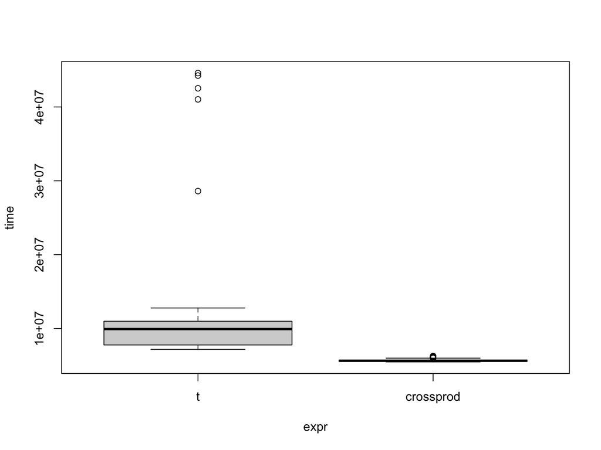

```r
plot(result)
```

# Takeaway: Profile your code before you start optimizing your code

- Profiling your code isn’t something happens inside your R package
- Instead, it’s something you do after you’ve written your function in your R package, find it suspiciously slow when you’re using it, and you fidget with it in the R console

# With the remaining time…

- A few more guidance about HW3
- Your `compute_maximal_partial_clique()` function should **not** take more than 30 seconds for a graph with 30 or less nodes!
- A bit more demo coding with ChatGPT

# Additional links

- TryCatch
- https://www.r-bloggers.com/2020/10/basic-error-handing-in-r-with-trycatch/
- Profiling your code
- https://bookdown.org/rdpeng/rprogdatascience/profiling-r-code.html
- Improving your code’s performance
- http://adv-r.had.co.nz/Performance.html